# Stat 202: Lecture 13 (student review)

Nathan VanHoudnos  
10/17/2014

### Agenda

1. Checkpoint results
2. Homework comments
3. Review

### Homework Results

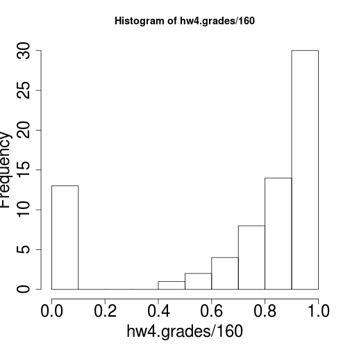

These are off by plus or minus `10/160 = .0625`

```r
mean(hw4.grades/160)
```

```
[1] 0.7055556
```

```r
median(hw4.grades/160)
```

```
[1] 0.84375
```

### Homework comments

Your grades are likely off by 10 pts (Question #4 part E):

- I distributed an incorrect solution set to both the TA and BlackBoard, and
- did not catch the error until **after** the the TA had graded your assignments (Thanks Stephanie!).

The correct solutions are now on BlackBoard, and in the hands of the TA.

Aaron will re-grade Question #4 part E on **Monday**.

> My apologies!

### Homework: Larry Summers

[Larry Summers](http://en.wikipedia.org/wiki/Lawrence_Summers)

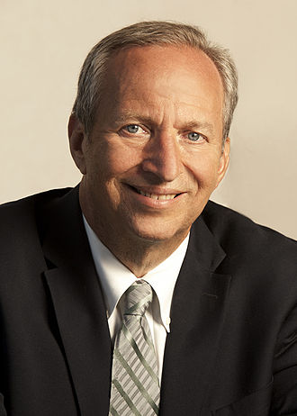

President of Harvard (2001-06)

- Gave a speech claiming that aptitude differences between men and women explained why men are over represented in science faculty positions.
- The speech was met with intense criticism
  - Resigned within a year
  - Cost him the US Treasury Secretary position in Obama's administration

### Teachable Moment: Larry's claim

From Question #5:

Can all three of the following statements be true?

1. The average woman is smarter than the average man.
2. In fact, 97.5% of women are smarter than the average man.
3. And yet, the top 2.5% of men are smarter than 99.85% of women.

### Teachable Moment: Larry's claim

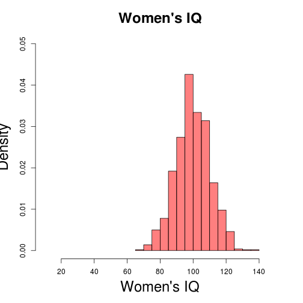

Assume that the IQs of men and women are distributed normally.

- Let the IQs of women be distributed with a mean of 100 and a standard deviation of 10.

### Teachable Moment: Larry's claim

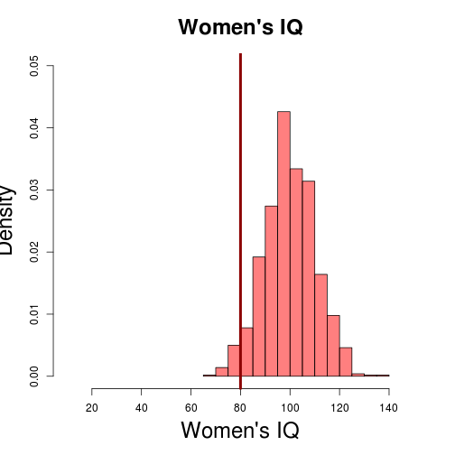

Assume that the IQs of men and women are distributed normally.

- Let the IQs of women be distributed with a mean of 100 and a standard deviation of 10.
- The 68-95-99.7 rule implies that .05/2 = 2.5% of women have an IQ below 80.

### Teachable Moment: Larry's claim

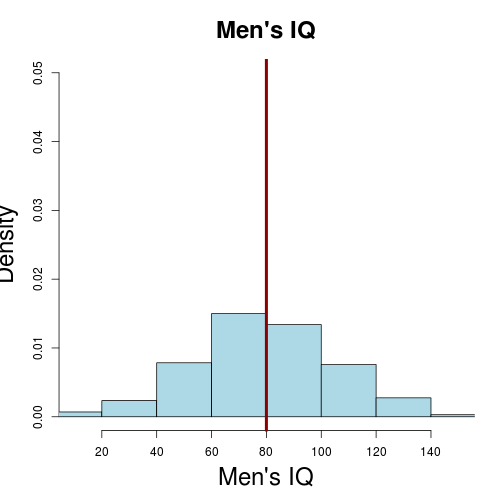

Assume that the IQs of men and women are distributed normally.

- Let the IQs of men be distributed with a mean of 80 and a standard deviation of 25.

### Teachable Moment: Larry's claim

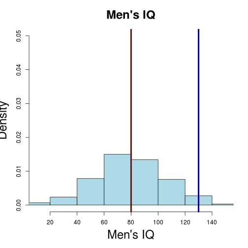

Assume that the IQs of men and women are distributed normally.

### Teachable Moment: Larry's claim

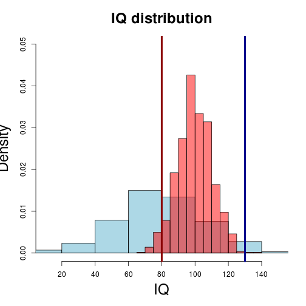

The 68-95-99.7 rule implies that

- 2.5% of men have an IQ over 130
- 0.003/2 = 0.15% of women have an IQ over 130

### Teachable Moment: Larry's claim

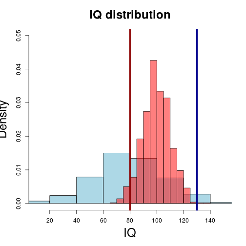

1. The average woman is smarter than the average man.
2. 97.5% of women are smarter than the average man.
3. And yet, the top 2.5% of men are smarter than 99.85% of women.

### Teachable Moment: Larry's claim

[What Larry said](http://en.wikipedia.org/wiki/Lawrence_Summers#Differences_between_the_sexes):

> “even small differences in the standard deviation [between genders] will translate into very large differences in the available pool substantially out [from the mean]”

If assume IQ is normally distributed and interpret

- “substantially out from the mean” as several standard deviations, and
- have evidence\( ^\text{[citation needed]} \) that the standard deviation of Men's and Women's IQ differs,

then Larry was was correct. (Question #6)

### Lessons from Larry

- Political discussions are rarely settled by mathematics because the **assumptions** of the two sides often differ.
  - The [Pinker v. Spelke debate](http://edge.org/3rd_culture/debate05/debate05_index.html) (2 hours!) barely touches upon the math, but focuses instead on Larry's assumptions.
- Your **assumptions** can be more important than your mathematics.
- If your assumptions are **strongly contrary** to the intuitions of your audience, you must provide **strong evidence** to counteract those intuitions.